# Species Description

Lucrecia Lipoma

2023-05-04

## *Gomphrena pulchella* Mart.

*Gomphrena pulchella* (spanish common name “Siempreviva del campo”)is a perennial herbaceus species from the opened patches in the xerophitic “Chacho forest” of Argentina. This plant can paint forest floor with its unique pink flowers and grayish green leaves.

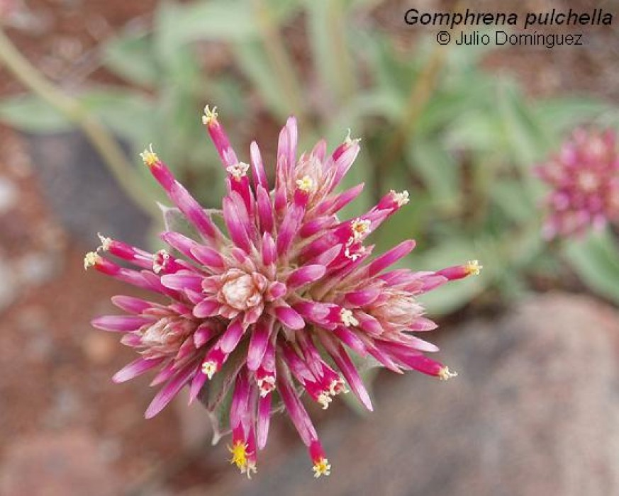

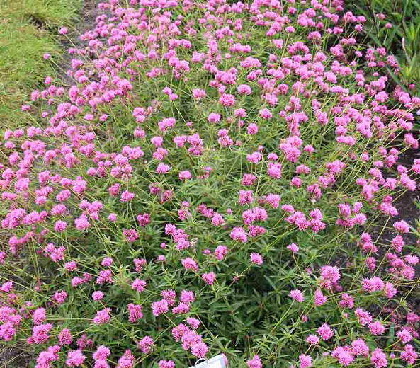

## **Taxonomy**

```r
library(taxlist)

gomphrena_sp <- new("taxlist")
levels(gomphrena_sp) <- c("species", "genus", "family", "kingdom")
levels(gomphrena_sp)
```

```
## [1] "species" "genus"   "family"  "kingdom"
```

```r
gomphrena_sp <- add_concept(gomphrena_sp, TaxonName = "Plantae", Level = "kingdom")
gomphrena_sp <- add_concept(gomphrena_sp, TaxonName = "Amaranthaceae", AuthorName="Juss.", Level = "family", Parent = 1)
gomphrena_sp <- add_concept(gomphrena_sp, TaxonName = "Gomphrena", AuthorName="L.", Level = "genus", Parent = 2)
gomphrena_sp <- add_concept(gomphrena_sp, TaxonName = "Gomphrena pulchella", AuthorName="Mart.", Level = "species", Parent = 3)

summary(gomphrena_sp, "all")
```

```
## ------------------------------
## concept ID: 1
## view ID: none
## level: kingdom
## parent: none
##
## # accepted name:
## 1 Plantae NA
## ------------------------------
## concept ID: 2
## view ID: none
## level: family
## parent: 1 Plantae NA
##
## # accepted name:
## 2 Amaranthaceae Juss.
## ------------------------------
## concept ID: 3
## view ID: none
## level: genus
## parent: 2 Amaranthaceae Juss.
##
## # accepted name:
## 3 Gomphrena L.
## ------------------------------
## concept ID: 4
## view ID: none
## level: species
## parent: 3 Gomphrena L.
##
## # accepted name:
## 4 Gomphrena pulchella Mart.
## ------------------------------
```

### Hierarchical structure

```r
indented_list(gomphrena_sp)
```

```
## Plantae NA
##  Amaranthaceae Juss.
##   Gomphrena L.
##    Gomphrena pulchella Mart.
```

## **Description**

This perennial herbaceous is distributed in xerophitic forests of Argentina, Bolivia, Brazil, Paraguay and Uruguay. It has been also introduced in Mexico.

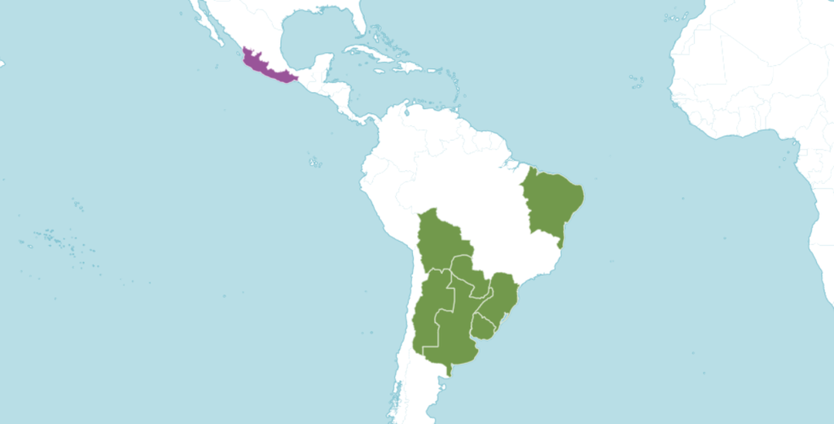

Distribution

It presents thick and very deep roots and a woody stem base, from which young and decumbent stems are born. Its leaves are elongated, reaching 2 or 3 cm long and have a silky appearance due to the presence of hairs. The pink flowers are arranged in globose heads of 2 to 3 cm in diameter. They appear from December to early autumn, but remain on the plant even when dry for a long time. This is the origin of its common name: *Siempreverde*.

It prefers opened areas, so it is commonly found in disturbed habitats such as roadsides.